# Raw reads expression analysis

source R profile. Memory was set to 500000.

```r
Sys.setenv("R_ENVIRON_USER"='/Users/castilln/.Renviron')
Sys.getenv("R_ENVIRON_USER")
```

```
[1] "/Users/castilln/.Renviron"
```

# Load expression data & spliceosome data

```r
raw_reads <- read_csv("/Users/castilln/Desktop/thesis/localdata/depmap/CCLE_RNAseq_reads.csv")
#rows: tumor sample barcode
#column: genes

sample_info <- read_csv("/Users/castilln/Desktop/thesis/localdata/depmap/sample_info.csv") #metadata
```

[output not shown]

```r
CCLE_mutations <- fread("/Users/castilln/Desktop/thesis/localdata/depmap/CCLE_info", header = TRUE) #mutations and sample info
```

[output not shown]

```r
mutations_spliceosome = fread("/Users/castilln/Desktop/thesis/localdata/depmap/mutations_spliceosome.csv")
```

Contingency table - Annotation of cell lines with spliceosome mutations

```r
cell_lines_list =
  CCLE_mutations %>%
  select(stripped_cell_line_name, primary_disease, DepMap_ID)

cell_lines_list_mutated =
 cell_lines_list %>%
   mutate(spliceosome_mutated =
           case_when(
            cell_lines_list$stripped_cell_line_name %in% mutations_spliceosome$stripped_cell_line_name ~ "YES", #if the mutation is in a gene from the spliceosome: 1
            !cell_lines_list$stripped_cell_line_name %in% mutations_spliceosome$stripped_cell_line_name ~ "NO")) %>%
  distinct()

cell_lines_list_mutated %>%
  distinct() %>%
  group_by(primary_disease,spliceosome_mutated) %>%
  tally()
```

| primary_disease | spliceosome_mutated | n |
| --- | --- | --- |
| Adrenal Cancer | YES | 1 |
| Bile Duct Cancer | NO | 3 |
| Bile Duct Cancer | YES | 33 |
| Bladder Cancer | YES | 39 |
| Bone Cancer | NO | 10 |
| Bone Cancer | YES | 65 |
| Brain Cancer | NO | 8 |
| Brain Cancer | YES | 99 |
| Breast Cancer | NO | 16 |
| Breast Cancer | YES | 66 |

[output cut: 48 more lines]

```r
table(distinct(cell_lines_list_mutated)$primary_disease,distinct(cell_lines_list_mutated)$spliceosome_mutated)
```

```
                              NO YES
  Adrenal Cancer               0   1
  Bile Duct Cancer             3  33
  Bladder Cancer               0  39
  Bone Cancer                 10  65
  Brain Cancer                 8  99
  Breast Cancer               16  66
  Cervical Cancer              0  22
  Colon/Colorectal Cancer      4  79
  Embryonal Cancer             0   3
  Endometrial/Uterine Cancer   1  38
  Engineered                   9   5
  Esophageal Cancer            0  38
  Eye Cancer                   0   9
  Fibroblast                   5  38
  Gallbladder Cancer           0   7
  Gastric Cancer               2  47
  Head and Neck Cancer         4  72
  Kidney Cancer                6  50
  Leukemia                     9 123
  Liposarcoma                  0  11
  Liver Cancer                 0  27
  Lung Cancer                 12 261
  Lymphoma                     4 105
  Myeloma                      1  33
  Neuroblastoma                1  45
  Non-Cancerous                2   3
  Ovarian Cancer               5  69
  Pancreatic Cancer            8  51
  Prostate Cancer              0  13
  Rhabdoid                     1  19
  Sarcoma                      7  35
  Skin Cancer                  7 106
  Teratoma                     0   1
  Thyroid Cancer               0  21
  Unknown                      9  36
```

```r
spliceosome_mutated_ID =
  cell_lines_list_mutated %>%
  select(DepMap_ID, spliceosome_mutated) %>%
  distinct()
```

```r
#Rename so that raw reads table has same variable name as metadata
raw_reads =
  raw_reads %>%
  rename("DepMap_ID" = "X1")

#join expression data with metadata
longraw_reads_info =
  raw_reads %>%
  pivot_longer(cols=-DepMap_ID, names_to = "Gene", values_to = "counts") %>%
  left_join(cell_lines_list_mutated, by = "DepMap_ID")

head(longraw_reads_info)
```

| DepMap_ID | Gene | counts | stripped_cell_line_name | primary_disease | spliceosome_mutated |
| --- | --- | --- | --- | --- | --- |
| ACH-001113 | TSPAN6 (ENSG00000000003) | 4.99050111 | LC1SQSF | Lung Cancer | YES |
| ACH-001113 | TNMD (ENSG00000000005) | 0.00000000 | LC1SQSF | Lung Cancer | YES |
| ACH-001113 | DPM1 (ENSG00000000419) | 7.27370237 | LC1SQSF | Lung Cancer | YES |
| ACH-001113 | SCYL3 (ENSG00000000457) | 2.76553475 | LC1SQSF | Lung Cancer | YES |
| ACH-001113 | C1orf112 (ENSG00000000460) | 4.48026512 | LC1SQSF | Lung Cancer | YES |
| ACH-001113 | FGR (ENSG00000000938) | 0.02856915 | LC1SQSF | Lung Cancer | YES |

```r
keep <- c("Bone Cancer", "Breast Cancer", "Fibroblast", "Leukemia", "Lung Cancer", "Ovarian Cancer", "Pancreatic Cancer", "Sarcoma", "Skin Cancer", "Non-Cancerous")

df_deseq =
longraw_reads_info %>%
  filter(primary_disease %in% keep)
```

Create a new column for ensembl gene ID

```r
df_deseq =
  df_deseq %>%
    separate(col = "Gene", into = c("Hugo_Symbol", "ensembl_id"), sep = "\\s")
```

```
Expected 2 pieces. Missing pieces filled with `NA` in 474496 rows [4638, 6273, 9775, 10891, 12752, 14264, 14270, 14719, 14967, 15478, 15553, 15575, 15679, 15948, 16166, 16322, 16643, 17025, 17173, 17322, ...].
```

```r
df_deseq$ensembl_id <- gsub("\\(|\\)","",as.character(df_deseq$ensembl_id))

head(df_deseq)
```

| DepMap_ID | Hugo_Symbol | ensembl_id | counts | stripped_cell_line_name | primary_disease | spliceosome_mutated |
| --- | --- | --- | --- | --- | --- | --- |
| ACH-001113 | TSPAN6 | ENSG00000000003 | 4.99050111 | LC1SQSF | Lung Cancer | YES |
| ACH-001113 | TNMD | ENSG00000000005 | 0.00000000 | LC1SQSF | Lung Cancer | YES |
| ACH-001113 | DPM1 | ENSG00000000419 | 7.27370237 | LC1SQSF | Lung Cancer | YES |
| ACH-001113 | SCYL3 | ENSG00000000457 | 2.76553475 | LC1SQSF | Lung Cancer | YES |
| ACH-001113 | C1orf112 | ENSG00000000460 | 4.48026512 | LC1SQSF | Lung Cancer | YES |
| ACH-001113 | FGR | ENSG00000000938 | 0.02856915 | LC1SQSF | Lung Cancer | YES |

## Preprocessing

Let’s visualize the distribution of the counts

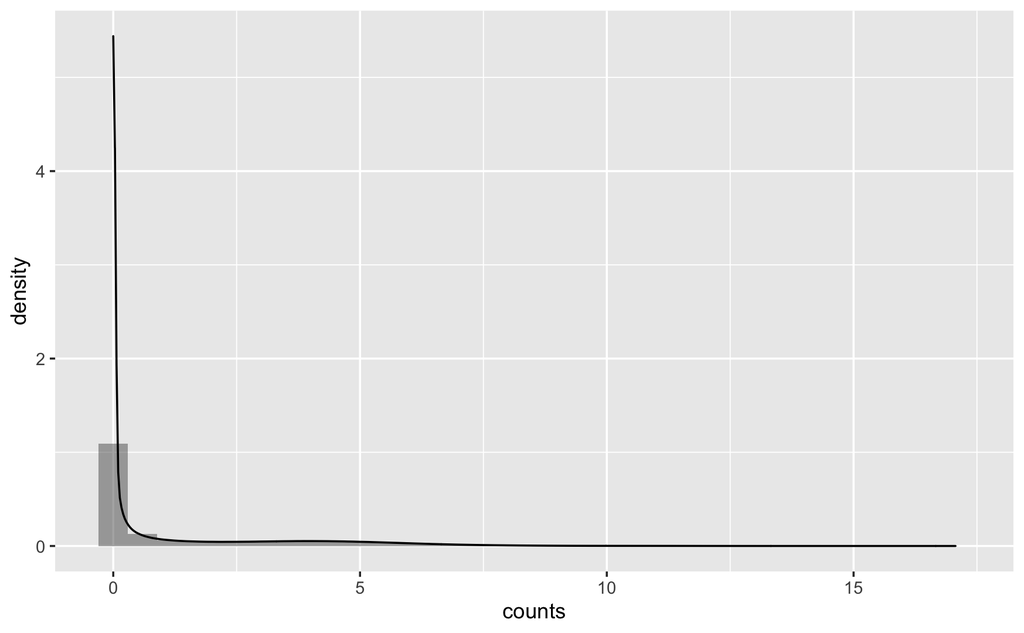

```r
library(ggdist)
ggplot(df_deseq, aes(x=counts)) +
  geom_histogram(aes(y=..density..), position="identity", alpha=0.5) +
  geom_density(alpha=0.6)
```

Filter out those genes whose median for expression is lower than 1 across all samples

```r
median_counts =
  df_deseq %>%
  group_by(Hugo_Symbol) %>%
  dplyr::mutate(median = median(counts, na.rm=TRUE)) %>%
  filter(median >= 1)
```

Plot again

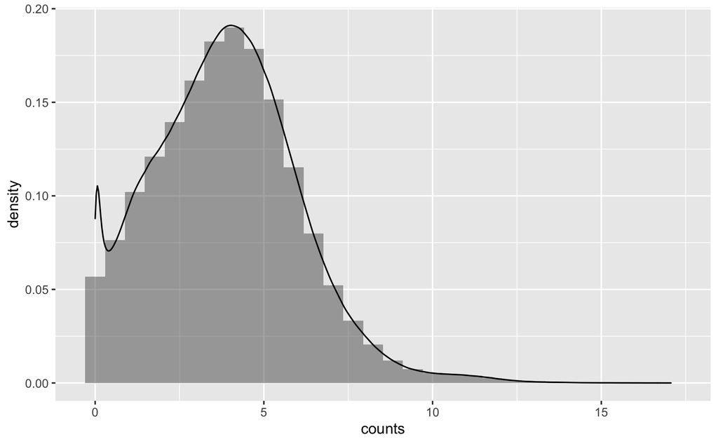

```r
ggplot(median_counts, aes(x=counts)) +
  geom_histogram(aes(y=..density..), position="identity", alpha=0.5) +
  geom_density(alpha=0.6)
```

Let’s calculate the counts-per-million (CPM) for each gene

```r
df_deseq = df_deseq %>%
  group_by(DepMap_ID) %>%
  mutate(cpm = 1e6 * (counts / sum(counts))) %>%
  ungroup()
```

# DGE List

A DGElist is an object that stores count matrix, sample metadata and gene annotation as one object and is used by edgeR

Create count matrix

```r
df_counts = df_deseq %>%
  select(ensembl_id,DepMap_ID,counts) %>%
  pivot_wider(names_from = DepMap_ID ,values_from = counts) %>%
  as.data.frame()
```

```
Values are not uniquely identified; output will contain list-cols.
* Use `values_fn = list` to suppress this warning.
* Use `values_fn = length` to identify where the duplicates arise
* Use `values_fn = {summary_fun}` to summarise duplicates
```

```r
#REMOVE NA VALUES FROM ENSEMBL ID COLUMN
df_counts <- df_counts[!is.na(df_counts$ensembl_id),]

#STORE FIRST COLUMN AS ROWNAMES
rownames(df_counts) = df_counts[,1]

#REMOVE FIRST COLUMN
df_counts = df_counts[,-1]

#CHECK IF THERE ARE NA VALUES
sum(is.na(df_counts))
```

```
[1] 0
```

```r
##THERE ARE NA VALUES IN DF_COUNTS. SUBSTITUTE NA VALUES BY THE MEAN EXPRESSION FOR THAT CELL LINE
#for(i in 1:ncol(df_counts)){
# df_counts[is.na(df_counts[,i]), i] <- mean(df_counts[,i], na.rm = TRUE)
#}
```

Create meta object. Meta only includes the data not specified in the raw reads file, therefore only cell line, spliceosome mutated status, primary disease and DepMap ID, which is what we are using as identifier.

```r
meta =
  df_deseq %>%
  ungroup() %>%
  select(-c("counts", "Hugo_Symbol", "ensembl_id", "cpm")) %>%
  distinct()

#CHANGE PRIMARY DISEASE NAMES SO THAT R CAN UNDERSTAND THEM, NECESSARY FOR DOWNSTREAM ANALYSIS
meta$primary_disease = gsub(" ", "_", meta$primary_disease)
meta$primary_disease = gsub("/", "_", meta$primary_disease)

head(meta)
```

| DepMap_ID | stripped_cell_line_name | primary_disease | spliceosome_mutated |
| --- | --- | --- | --- |
| ACH-001113 | LC1SQSF | Lung_Cancer | YES |
| ACH-001339 | COLO794 | Skin_Cancer | YES |
| ACH-000327 | NCIH1395 | Lung_Cancer | YES |
| ACH-000705 | LC1F | Lung_Cancer | YES |
| ACH-000528 | ABC1 | Lung_Cancer | YES |
| ACH-001098 | KCIMOH1 | Pancreatic_Cancer | YES |

Create grouping factor

```r
meta =
  meta %>%
  mutate(group = as.factor(spliceosome_mutated)) %>%
  select(-spliceosome_mutated) %>%
  mutate(primary_disease = as.factor(primary_disease))
```

Reorder count columns by meta ID

```r
##REORDER COLUMNS BY SAMPLE INFO
df_counts = df_counts[meta$DepMap_ID]

##NEED TO BE CHARACTER SO THAT THEY CAN BE STORED IN DGEList
df_counts[] <- lapply(df_counts, function(x) as.numeric(as.character(x)))

head(df_counts)
```

|  | ACH-001113 | ACH-001339 | ACH-000327 | ACH-000705 | ACH-000528 | ACH-001098 | ACH-000769 | ACH-000154 | ACH-000828 | ACH-000765 | ACH-001375 | ACH-000008 | ACH-001814 | ACH-000800 | ACH-000123 | ACH-002066 | ACH-000728 | ACH-000700 | ACH-000006 | ACH-001377 | ACH-000465 | ACH-000138 | ACH-000117 | ACH-000520 | ACH-000176 | ACH-000017 | ACH-000020 | ACH-000587 | ACH-000785 | … |
| --- | --- | --- | --- | --- | --- | --- | --- | --- | --- | --- | --- | --- | --- | --- | --- | --- | --- | --- | --- | --- | --- | --- | --- | --- | --- | --- | --- | --- | --- | --- |
| ENSG00000000003 | 4.99050111 | 3.77925972 | 4.03298242 | 5.10139795 | 5.23649262 | 6.706807 | 5.419202 | 3.99095486 | 4.130931 | 3.60644223 | 4.58436125 | 3.467279 | 5.21606678 | 3.62760684 | 3.5298209 | 5.27463440 | 0.12432814 | 1.18903382 | 0.1634987 | 5.41142625 | 4.2024177 | 5.22573765 | 4.05050170 | 4.07382023 | 1.50589093 | 3.09085343 | 0.09761080 | 4.92552477 | 5.7186356 | … |
| ENSG00000000005 | 0.00000000 | 0.00000000 | 0.00000000 | 0.00000000 | 0.00000000 | 0.000000 | 0.000000 | 0.00000000 | 0.000000 | 0.00000000 | 0.00000000 | 0.000000 | 0.00000000 | 0.00000000 | 0.2509616 | 0.00000000 | 0.00000000 | 0.00000000 | 0.0000000 | 0.00000000 | 0.0000000 | 0.00000000 | 0.05658353 | 0.00000000 | 0.02856915 | 0.00000000 | 0.00000000 | 0.00000000 | 0.0000000 | … |
| ENSG00000000419 | 7.27370237 | 7.34642509 | 5.80658184 | 6.30997649 | 7.00584908 | 6.726559 | 6.109152 | 6.17632277 | 5.817879 | 7.38663853 | 7.17412674 | 7.092229 | 7.55765515 | 6.53511982 | 6.4495614 | 8.28262513 | 5.63546420 | 7.24155421 | 6.1151997 | 7.31152128 | 6.1220514 | 6.30451104 | 7.60251330 | 6.30414594 | 6.99909803 | 7.00067610 | 5.52700776 | 6.18804480 | 6.1973150 | … |
| ENSG00000000457 | 2.76553475 | 2.33913738 | 1.94860085 | 2.36176836 | 2.82984956 | 3.258519 | 2.446256 | 2.36457243 | 3.891419 | 2.51096192 | 2.23878686 | 2.204767 | 1.54596837 | 2.52857132 | 1.7484612 | 2.57531233 | 3.20789285 | 2.00360224 | 2.7697717 | 3.28540222 | 2.5160151 | 2.85399565 | 2.98550043 | 1.87184365 | 2.01792191 | 3.27202319 | 2.58255600 | 2.08065766 | 2.9259994 | … |
| ENSG00000000460 | 4.48026512 | 4.25474520 | 2.68481874 | 4.28021400 | 4.66675659 | 3.127633 | 4.191405 | 3.32337007 | 3.651913 | 3.89141919 | 4.86046626 | 4.125982 | 3.01256867 | 4.33985000 | 3.1651080 | 3.34056227 | 4.74308406 | 4.24564777 | 4.2055489 | 4.69376571 | 3.6438562 | 3.51475350 | 3.67807191 | 3.37295210 | 3.60288441 | 3.89530262 | 3.96716861 | 3.31469653 | 2.6599246 | … |
| ENSG00000000938 | 0.02856915 | 0.05658353 | 0.01435529 | 0.02856915 | 0.01435529 | 0.000000 | 0.000000 | 0.02856915 | 0.000000 | 0.01435529 | 0.05658353 | 0.000000 | 0.02856915 | 0.01435529 | 0.0000000 | 0.05658353 | 0.01435529 | 0.01435529 | 3.8718436 | 0.02856915 | 0.2986583 | 0.01435529 | 0.01435529 | 0.02856915 | 0.01435529 | 0.01435529 | 0.02856915 | 0.01435529 | 0.1110313 | … |

```r
NA
```

Create gene annotation

```r
#SOMETIMES PROBLEMS TO LOAD THIS LIBRARIES BECAUSE INCOMPATIBILITIES W/ COMPLEX HEATMAP: START NEW R SESSION
library("AnnotationDbi")
library("org.Hs.eg.db")
```

```r
gene_annot = AnnotationDbi::mapIds(org.Hs.eg.db, keys=rownames(df_counts),
       column=c("SYMBOL"), keytype="ENSEMBL") %>%
  as.data.frame()
gene_desc = AnnotationDbi::mapIds(org.Hs.eg.db, keys=rownames(df_counts),
       column=c("GENENAME"), keytype="ENSEMBL") %>%
  as.data.frame()
gene_annot = cbind(gene_annot,gene_desc)

colnames(gene_annot) = c("SYMBOL","DESCRIPTION")

head(gene_annot)
```

|  | SYMBOL | DESCRIPTION |
| --- | --- | --- |
| ENSG00000000003 | TSPAN6 | tetraspanin 6 |
| ENSG00000000005 | TNMD | tenomodulin |
| ENSG00000000419 | DPM1 | dolichyl-phosphate mannosyltransferase subunit 1, catalytic |
| ENSG00000000457 | SCYL3 | SCY1 like pseudokinase 3 |
| ENSG00000000460 | C1orf112 | chromosome 1 open reading frame 112 |
| ENSG00000000938 | FGR | FGR proto-oncogene, Src family tyrosine kinase |

Now, let’s create the DGElist

```r
dge = DGEList(counts = df_counts,
              samples = meta,
              genes = gene_annot)

summary(dge)
```

```
        Length   Class      Mode
counts  34575526 -none-     numeric
samples        6 data.frame list
genes          2 data.frame list
```

# Filtering and pre-process

Remove genes for which we do not know annotation: NA Symbol. In order to avoid duplicates

```r
i <- is.na(dge$genes$SYMBOL)
dge <- dge[!i, ]
```

Filter lowly expressed genes

```r
#keep = filterByExpr(dge)
#dge = dge[keep, , keep.lib.sizes=FALSE]
```

Calculate library normalization factors (effective library size)

```r
#dge <- calcNormFactors(dge)
#dge$samples
```

# MDS

Plot MDS (quality control to detect outliers/bad samples)

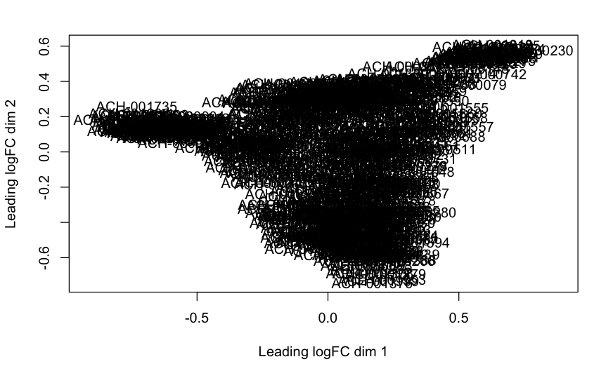

```r
plotMDS(dge)
```

# Differential expression

Set up design matrix

```r
design = model.matrix(~primary_disease + group, data = dge$samples)

colnames(design)
```

```
 [1] "(Intercept)"                      "primary_diseaseBreast_Cancer"     "primary_diseaseFibroblast"
 [4] "primary_diseaseLeukemia"          "primary_diseaseLung_Cancer"       "primary_diseaseOvarian_Cancer"
 [7] "primary_diseasePancreatic_Cancer" "primary_diseaseSarcoma"           "primary_diseaseSkin_Cancer"
[10] "groupYES"
```

```r
#design
```

Filter lowly expressed genes (here they suggets to do it after setting up a design: https://www.biostars.org/p/430379/)

```r
#keep = filterByExpr(dge, design)

#IF WE DO NOT WANT TO TEST FOR DIFFERENTIAL EXPRESSION BETWEEN CANCERS:
keep = filterByExpr(dge, group = dge$sample$group)

dge = dge[keep, , keep.lib.sizes=FALSE]
```

Calculate library normalization factors (effective library size)

```r
dge <- calcNormFactors(dge)
dge$samples
```

|  | group | lib.size | norm.factors | DepMap_ID | stripped_cell_line_name | primary_disease |
| --- | --- | --- | --- | --- | --- | --- |
| ACH-001113 | YES | 3420.963 | 0.9919360 | ACH-001113 | LC1SQSF | Lung_Cancer |
| ACH-001339 | YES | 3548.328 | 0.9827451 | ACH-001339 | COLO794 | Skin_Cancer |
| ACH-000327 | YES | 3197.109 | 0.9878414 | ACH-000327 | NCIH1395 | Lung_Cancer |
| ACH-000705 | YES | 3355.564 | 0.9969340 | ACH-000705 | LC1F | Lung_Cancer |
| ACH-000528 | YES | 3450.768 | 0.9963460 | ACH-000528 | ABC1 | Lung_Cancer |
| ACH-001098 | YES | 3472.713 | 0.9989571 | ACH-001098 | KCIMOH1 | Pancreatic_Cancer |
| ACH-000769 | YES | 3328.149 | 1.0299948 | ACH-000769 | LK2 | Lung_Cancer |
| ACH-000154 | NO | 3514.920 | 0.9599389 | ACH-000154 | HS888T | Fibroblast |
| ACH-000828 | YES | 3294.893 | 1.0056161 | ACH-000828 | ZR7530 | Breast_Cancer |
| ACH-000765 | YES | 3437.856 | 0.9948837 | ACH-000765 | WM983B | Skin_Cancer |

[output cut: 664 more lines]

Estimate dispersion

```r
dge = estimateDisp(dge, design)
```

Fit a negative binomial generalized linear model to our data

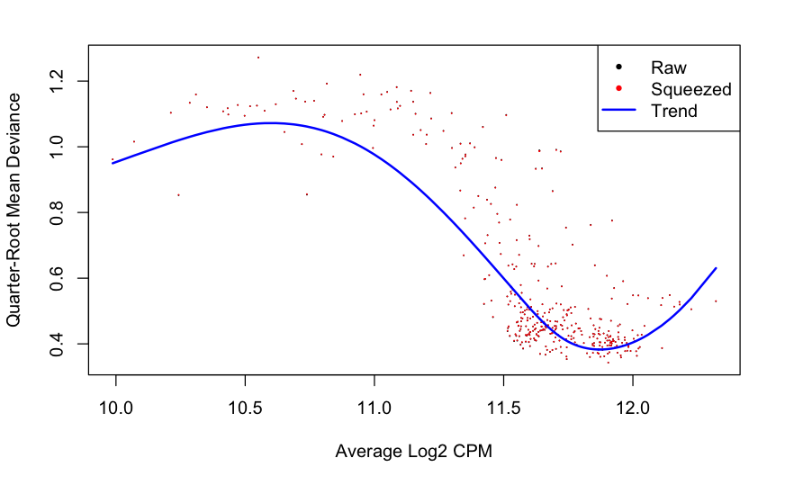

```r
fit <- glmQLFit(dge, design)

plotQLDisp(fit)
```

In order to compare the difference in cell lines with spliceosome mutations vs wt for all different cancers, we need to define some contrasts for the model.

```r
my.contrasts <- makeContrasts(
  YvsN = `groupYES`- `groupNO`,
  levels = design
)
```

```
Renaming (Intercept) to InterceptError in eval(ej, envir = levelsenv) : object 'groupNO' not found
```

```r
qlf.spliceosome.YvsN <- glmQLFTest(fit)
topTags(qlf.spliceosome.YvsN)
```

```
Coefficient:  groupYES
```

|  | SYMBOL | DESCRIPTION | logFC | logCPM | F | PValue | FDR |
| --- | --- | --- | --- | --- | --- | --- | --- |
| ENSG00000160307 | S100B | S100 calcium binding protein B | 1.2006774 | 9.98740 | 13.619072 | 0.0002421427 | 0.09395135 |
| ENSG00000163220 | S100A9 | S100 calcium binding protein A9 | 0.7070092 | 10.30934 | 4.122890 | 0.0427023207 | 0.99896685 |
| ENSG00000129824 | RPS4Y1 | ribosomal protein S4 Y-linked 1 | -0.4890743 | 10.55113 | 3.238242 | 0.0723888560 | 0.99896685 |
| ENSG00000164692 | COL1A2 | collagen type I alpha 2 chain | -0.4235258 | 10.35201 | 2.969969 | 0.0852861400 | 0.99896685 |
| ENSG00000185664 | PMEL | premelanosome protein | 0.3181377 | 10.24247 | 3.127652 | 0.0921404703 | 0.99896685 |
| ENSG00000167644 | C19orf33 | chromosome 19 open reading frame 33 | -0.3008447 | 10.80702 | 2.358635 | 0.1250645375 | 0.99896685 |
| ENSG00000102879 | CORO1A | coronin 1A | 0.1930223 | 10.73884 | 2.734615 | 0.1452576612 | 0.99896685 |
| ENSG00000105974 | CAV1 | caveolin 1 | -0.1897374 | 11.09037 | 1.869530 | 0.1719886778 | 0.99896685 |
| ENSG00000163993 | S100P | S100 calcium binding protein P | 0.3717907 | 10.47145 | 1.851120 | 0.1741119963 | 0.99896685 |
| ENSG00000234745 | HLA-B | major histocompatibility complex, class I, B | 0.1312465 | 11.49164 | 2.100328 | 0.1822698191 | 0.99896685 |

Likelihood radio tests

```r
topTags(lrt)
```

[output not shown]

```
Coefficient:  groupYES
```

|  | SYMBOL | DESCRIPTION | logFC | logCPM | LR | PValue | FDR |
| --- | --- | --- | --- | --- | --- | --- | --- |
| ENSG00000160307 | S100B | S100 calcium binding protein B | 1.2006774 | 9.98740 | 11.648376 | 0.0006425861 | 0.2493234 |
| ENSG00000129824 | RPS4Y1 | ribosomal protein S4 Y-linked 1 | -0.4890743 | 10.55113 | 8.459449 | 0.0036315188 | 0.7045147 |
| ENSG00000163220 | S100A9 | S100 calcium binding protein A9 | 0.7070092 | 10.30934 | 7.435121 | 0.0063963060 | 0.8272556 |
| ENSG00000164692 | COL1A2 | collagen type I alpha 2 chain | -0.4235258 | 10.35201 | 4.673903 | 0.0306242491 | 0.9989525 |
| ENSG00000167644 | C19orf33 | chromosome 19 open reading frame 33 | -0.3008447 | 10.80702 | 3.418549 | 0.0644676668 | 0.9989525 |
| ENSG00000163993 | S100P | S100 calcium binding protein P | 0.3717907 | 10.47145 | 2.987180 | 0.0839262182 | 0.9989525 |
| ENSG00000105974 | CAV1 | caveolin 1 | -0.1897374 | 11.09037 | 2.903182 | 0.0884048566 | 0.9989525 |
| ENSG00000130513 | GDF15 | growth differentiation factor 15 | 0.2292875 | 10.87515 | 2.167631 | 0.1409432307 | 0.9989525 |
| ENSG00000154277 | UCHL1 | ubiquitin C-terminal hydrolase L1 | -0.1601105 | 11.04935 | 1.837703 | 0.1752203797 | 0.9989525 |
| ENSG00000234745 | HLA-B | major histocompatibility complex, class I, B | 0.1312465 | 11.49164 | 1.778051 | 0.1823888630 | 0.9989525 |

```r
summary(decideTests(qlf.spliceosome.YvsN))
```

```
       groupYES
Down          0
NotSig      388
Up            0
```

Duplicate elements? FIX

```r
#THERE SEEM TO BE SOME DUPLICATED ELEMENTS. REMOVE NA
qlf.spliceosome.YvsN %>%
  duplicated()
```

```
 [1] FALSE FALSE FALSE FALSE FALSE FALSE FALSE FALSE FALSE FALSE FALSE FALSE FALSE  TRUE FALSE FALSE FALSE
[18] FALSE FALSE FALSE FALSE FALSE FALSE
```

Adjust p-values (FDR) and merge data into a single table to facilitate the analysis:

```r
TidyQLF = function(qlf, contrast) {
  df_qlf =
    qlf$table %>%
    as_tibble(rownames = "SYMBOL") %>%
    mutate(FDR = p.adjust(PValue, method = "fdr"))

  df_full =
    cbind(qlf$genes,df_qlf) %>%
    mutate(comparison = contrast) %>%
    relocate(SYMBOL, .before = DESCRIPTION) %>%
    relocate(comparison, .before = SYMBOL)

  return(df_full)
}


tbl_YvsN = TidyQLF(qlf.spliceosome.YvsN,"YesvsNo")


head(tbl_YvsN)
```